# Laboratorio 3

## PARTE 2

Para la parte dos del laboratorio nos pedian utilizar parte del laboratorio anterior para poder trabajar, por eso, nosotros usamos los datos de importacion del laboratorio anterior

```r
impor<-read_excel("Importacion.xlsx")
```

Una vez hecha esta parte, empezamos a modificar los datos para que sea trabajable con el LSTM

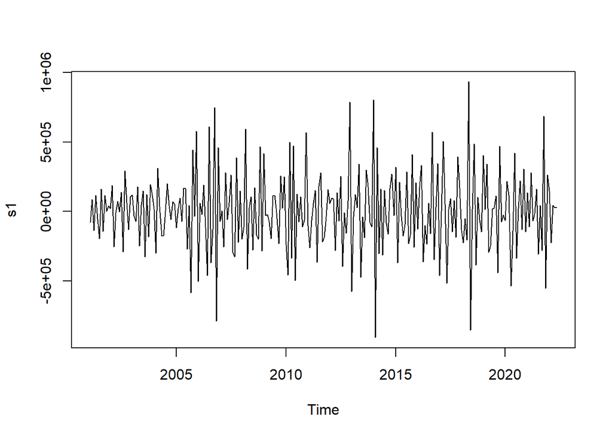

```r
fd <- impor[c('Fecha','Diesel')]
diesel_ts <- ts(fd$Diesel, start = c(2001, 1),frequency = 12)
s1<-diff(diesel_ts)
plot(s1)
```

Y como podemos observar obtenemos una grafica que nos muestra los datos de importacion de combustible Diesel desde el año 2001.

Ahora debemos de normalizar la serie, esto con la finalidad de que el LSTM pueda ser mas efectivo, asi como tambien creamos una serie supervisada.

```r
norm_s1<-scale(s1)

lgd <-c(rep(NA, 1),norm_s1[1:(length(norm_s1)-1)])
supervised <-as.data.frame(cbind(lgd,norm_s1))
colnames(supervised)<-c("x-1", "x")
supervised[is.na(supervised)]<-0
```

Ahora fraccionamos la serie, 60% para entrenamiento, 20% para validación y 20% para prueba

```r
entrenamiento<-round(0.6*length(s1))
val_test<-round(0.2*length(s1))
test<-tail(supervised, val_test)
supervised<-supervised %>% head(nrow(.)-val_test)
validation<-supervised %>% tail(val_test)
supervised<-head(supervised, nrow(supervised)-val_test)
#El train son los que quedan
train<-supervised
rm(supervised)


y_train <- train[,2]
x_train <- train[,1]
y_val <- validation[,2]
x_val <- validation[,1]
y_test <- test[,2]
x_test <- test[,1]
```

Y para poder trabajarlo, debemos de convertir a matrices:

```r
paso <- 1
caracteristicas<-1 #es univariada
dim(x_train) <- c(length(x_train),paso,caracteristicas)
dim(y_train) <- c(length(y_train),caracteristicas)
dim(x_test) <- c(length(x_test),paso,caracteristicas)
dim(y_test) <- c(length(y_test),caracteristicas)
dim(x_val) <- c(length(x_val),paso,caracteristicas)
dim(y_val) <- c(length(y_val),caracteristicas)
```

Con todos estos pasos hechos, con la preparacion de la serie para el LSTM, ahora ya podemos crear el MODELO del LSTM, por lo cual, procederemos a crear el primer modelo:

### MODELO #1

```r
lote = 1
unidades <- 1
modelo1 <-keras_model_sequential()
```

```
## Loaded Tensorflow version 2.9.1
```

```r
modelo1 %>%
  layer_lstm(unidades, batch_input_shape=c(lote, paso, caracteristicas),
             stateful = T) %>%
  layer_dense(units = 1)

summary(modelo1)
```

```
## Model: "sequential"
## ________________________________________________________________________________
##  Layer (type)                       Output Shape                    Param #
## ================================================================================
##  lstm (LSTM)                        (1, 1)                          12
##  dense (Dense)                      (1, 1)                          2
## ================================================================================
## Total params: 14
## Trainable params: 14
## Non-trainable params: 0
## ________________________________________________________________________________
```

```r
modelo1 %>%
  compile(
    optimizer = 'rmsprop',
    loss = 'mse'
  )
```

Entrenamos el modelo y graficamos lo que llevamos al momento

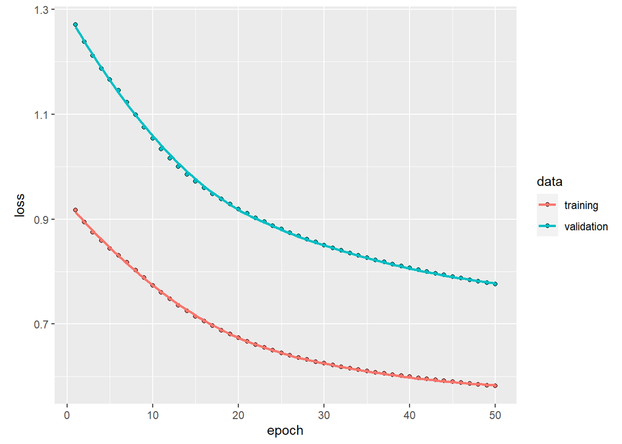

```r
epocas <- 50
history <- modelo1 %>% fit(
  x = x_train,
  y = y_train,
  validation_data = list(x_val, y_val),
  batch_size = lote,
  epochs = epocas,
  shuffle = FALSE,
  verbose = 0
)

plot(history)
```

Evaluamos el modelo en sus diferentes partes, entrenamiento, validacion y prueba

```r
print("Entrenamiento")
```

```
## [1] "Entrenamiento"
```

```r
modelo1 %>% evaluate(
  x = x_train,
  y = y_train
)
```

```
##     loss
## 1.212252
```

```r
print("Validación")
```

```
## [1] "Validación"
```

```r
modelo1 %>% evaluate(
  x = x_val,
  y = y_val
)
```

```
##    loss
## 1.21814
```

```r
print("Prueba")
```

```
## [1] "Prueba"
```

```r
modelo1 %>% evaluate(
  x = x_test,
  y = y_test
)
```

```
##     loss
## 1.380902
```

Luego de esto, solo resta crear una prediccion para el modelo, con lo cual tenemos:

```r
prediccion_fun <- function(data,modelo, batch_size,scale,center,dif=F, Series=NULL,n=1){
  prediccion <- numeric(length(data))
  if (dif==F){
    for(i in 1:length(data)){
      X = data[i]
      dim(X) = c(1,1,1)
      yhat = modelo %>% predict(X, batch_size=batch_size)
      # invert scaling
      yhat = yhat*scale+center
      # store
      prediccion[i] <- yhat
    }
  }else{
    for(i in 1:length(data)){
      X = data[i]
      dim(X) = c(1,1,1)
      yhat = modelo1 %>% predict(X, batch_size=batch_size)
      # invert scaling
      yhat = yhat*scale+center
      # invert differencing
      yhat  = yhat + Series[(n+i)]
      # store
      prediccion[i] <- yhat
    }
  }

  return(prediccion)
}

prediccion_val <- prediccion_fun(x_val,modelo1,1,attr(norm_s1,"scaled:scale"),
                                 attr(norm_s1,"scaled:center"),dif=T,s1,entrenamiento
)
prediccion_test <- prediccion_fun(x_test,modelo1,1,attr(norm_s1,"scaled:scale"),
                                  attr(norm_s1,"scaled:center"),dif=T,s1,entrenamiento+val_test
)
```

Y por ultimo, solo nos queda graficar el modelo para poder compararlo con los modelos de ARIMA.

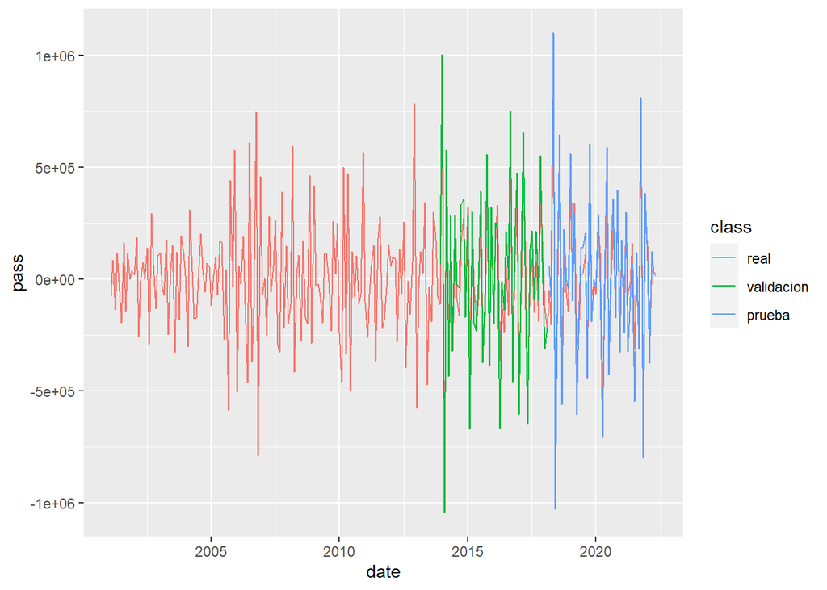

```r
serie<-s1
serie_test<- tail(serie,val_test)
serie<-head(serie,length(serie)-val_test)
serie_val<-tail(serie,val_test)
serie<-head(serie,length(serie)-val_test)
serie_train <- serie


df_serie_total<-data.frame(pass=as.matrix(s1), date=zoo::as.Date(time(s1)))
df_serie_val<-data.frame(pass=prediccion_val, date=zoo::as.Date(time(serie_val)))
df_serie_test<-data.frame(pass=prediccion_test, date=zoo::as.Date(time(serie_test)))


df_serie_total$class <- 'real'
df_serie_val$class <- 'validacion'
df_serie_test$class <- 'prueba'

df_serie<-rbind(df_serie_total, df_serie_val,df_serie_test)
df_serie$class<-factor(df_serie$class,levels = c('real','validacion','prueba'))
ggplot(df_serie,aes(x = date, y = pass, colour = class)) +
  geom_line()
```